[figure not shown]

# Simulación de modelos mixtos

Freddy Hernández

2019-febrero-02

## Introducción

En esta publicación se mostrará al lector cómo simular datos de modelos lineales y la forma de estimar los parámetros. Los modelos a simular son:

1. Modelo lineal clásico,
2. Modelo lineal con intercepto aleatorio,
3. Modelo lineal con pendiente aleatoria,
4. Modelo lineal con intercepto y pendiente aleatoria.

## Ilustración de un modelo mixto

Se recomienda al lector que visite el enlace mostrado abajo para que vea una ilustración muy interesante de modelos mixtos. Los parámetros usados en las simulaciones fueron inspirados en la ilustración.

http://mfviz.com/hierarchical-models/

## Simulando datos de modelo lineal clásico

Suponga que queremos simular $n=50$ observaciones del siguiente modelo con vector de parámetros $\boldsymbol{\Theta}=(\beta_0=59, \beta_1=1, \sigma=1)^\top$.

$$\begin{align*}
y_i &\sim \mathcal{N}(\mu_i, \sigma^2) \\
\mu_i &= 59 + 1 x_i \\
\sigma &= 1 \\
x &\sim Uniforme[1, 9]
\end{align*}$$

Con el siguiente código se simula el conjunto de datos de interés.

```r
n <- 50
x <- sample(1:9, size=n, replace=TRUE) # Uniforme discreta [1, 9]
sig <- 1
media <- 59 + 1 * x
y <- rnorm(n=n, mean=media, sd=sig)
```

Vamos a construir un diagrama de dispersión para los datos simulados.

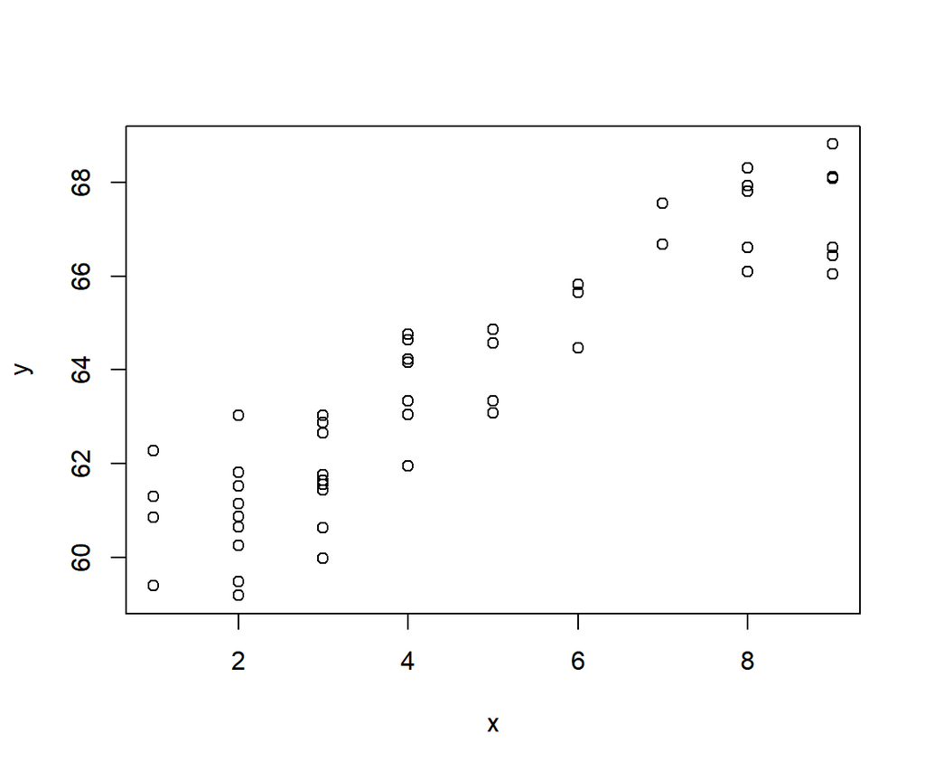

```r
plot(y ~ x)
```

Ajustemos un modelo para recuperar el vector de parámetros parámetros $\boldsymbol{\Theta}$.

```r
mod1 <- lm(y ~ x)
c(mod1$coef, sigma=summary(mod1)$sigma)
```

```
## (Intercept)           x       sigma
##  59.3172073   0.9546495   1.0931852
```

De la salida anterior vemos que vector de parámetros estimado está cerca de $\boldsymbol{\Theta}=(\beta_0=59, \beta_1=1, \sigma=1)^\top$.

Vamos a agregar la línea del modelo ajustado.

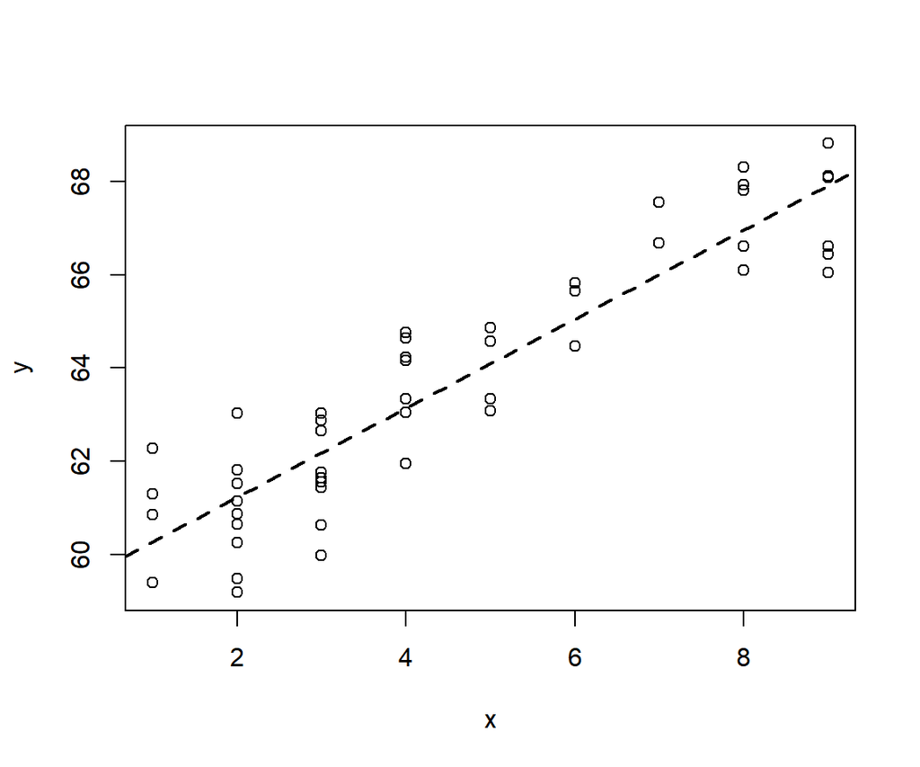

```r
plot(y ~ x)
abline(mod1, lty='dashed', lwd=2)
```

## Simulando datos con intercepto aleatorio

Suponga que ahora queremos simular $n_i=10$ observaciones para $n_g=5$ grupos (en total 50) usando el siguiente modelo mixto con *intercepto aleatorio* con vector de parámetros $\boldsymbol{\Theta}=(\beta_0=59, \beta_1=1, \sigma=1, \sigma_{b0}=10)^\top$.

$$\begin{align*}
y_{ij} &\sim \mathcal{N}(\mu_{ij}, \sigma^2) \\
\mu_{ij} &= 59 + 1 \, x_{ij} + b_{0i} \\
\sigma &= 1 \\
b_0 &\sim \mathcal{N}(0, \sigma_{b0}) \\
x &\sim Uniforme[1, 9] \\
i &= 1, 2, \ldots, n_g \quad j=1, 2, \ldots, n_i
\end{align*}$$

```r
sig <- 1
sd_b0 <- 10

ng <- 5        # número de grupos
ni <- 10       # número de obs por grupo
n <- ng * ni   # número de obs total

grupo <- rep(1:5, each=ni) # Variable de agrupación

x <- sample(1:9, size=n, replace=TRUE)
b0 <- rnorm(n=ng, mean=0, sd=sd_b0)  # Vector con los cinco b0
b0_rep <- rep(b0, each=ni)           # Vector con los b0 repetidos
media <- 59 + 1 * x + b0_rep
y <- rnorm(n=n, mean=media, sd=sig)

dt <- data.frame(grupo=grupo, x=x, b0_rep, y=y)
```

Exploremos lo que hay dentro de `dt`.

```r
dt[1:15, ]
```

```
##    grupo x    b0_rep        y
## 1      1 6 16.120339 81.56285
## 2      1 7 16.120339 80.24733
## 3      1 5 16.120339 80.04034
## 4      1 2 16.120339 76.04057
## 5      1 3 16.120339 79.45743
## 6      1 7 16.120339 82.60536
## 7      1 9 16.120339 84.49406
## 8      1 4 16.120339 79.51302
## 9      1 4 16.120339 77.97654
## 10     1 7 16.120339 82.83345
## 11     2 3 -3.119691 58.29140
## 12     2 4 -3.119691 57.66140
## 13     2 1 -3.119691 56.96945
## 14     2 6 -3.119691 60.13796
## 15     2 4 -3.119691 59.27011
```

Vamos a construir un diagrama de dispersión para los datos simulados.

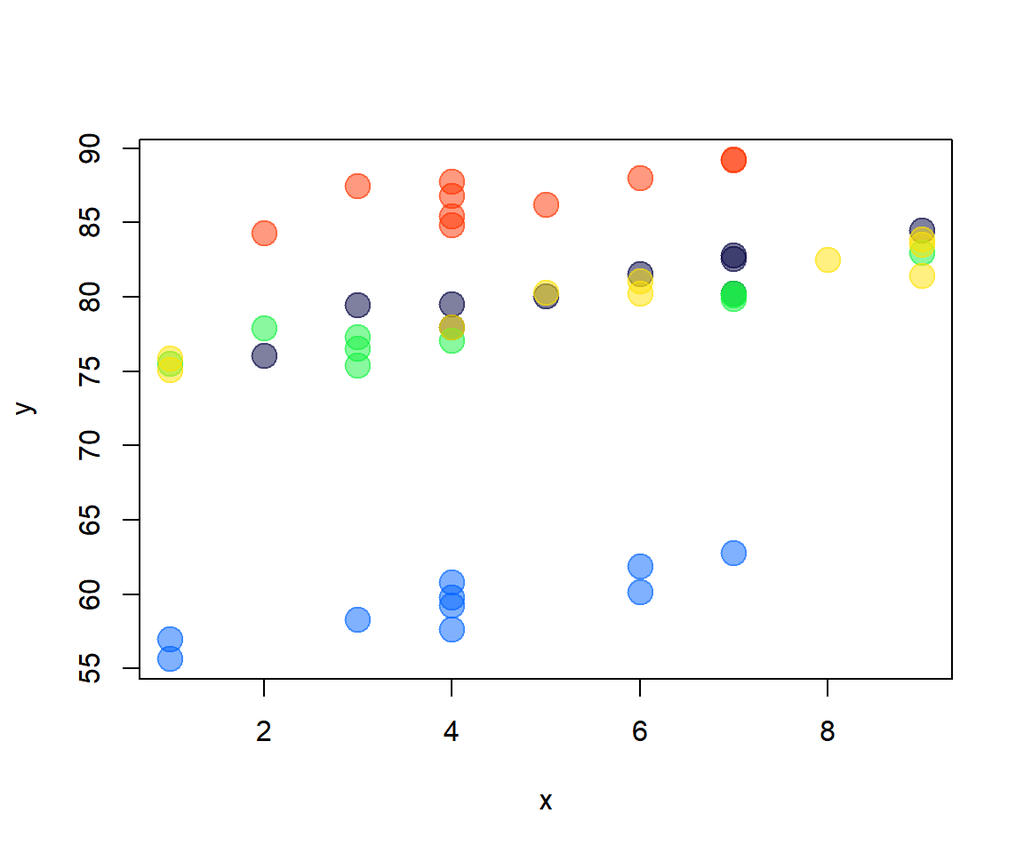

```r
colores <- c("#00004080", "#0063FF80", "#13F24080", "#FFE20180", "#FF330080")
with(dt, plot(y ~ x, pch=20, col=colores[dt$grupo], cex=3))
```

Ajustemos un modelo para recuperar el vector de parámetros parámetros $\boldsymbol{\Theta}$, para esto usemos la función `lme` del paquete `nlme`.

```r
library(nlme)
mod2 <- lme(y ~ x, random = ~ 1 | grupo, data=dt)
summary(mod2)
```

```
## Linear mixed-effects model fit by REML
##  Data: dt
##       AIC      BIC    logLik
##   179.899 187.3838 -85.94951
##
## Random effects:
##  Formula: ~1 | grupo
##         (Intercept)  Residual
## StdDev:    10.05218 0.9837666
##
## Fixed effects: y ~ x
##                Value Std.Error DF  t-value p-value
## (Intercept) 72.49110  4.507746 44 16.08145       0
## x            0.93291  0.061871 44 15.07840       0
##  Correlation:
##   (Intr)
## x -0.067
##
## Standardized Within-Group Residuals:
##        Min         Q1        Med         Q3        Max
## -1.7479864 -0.6609473  0.0619048  0.6435406  2.1013585
##
## Number of Observations: 50
## Number of Groups: 5
```

De la tabla anterior vemos que el vector de parámetros estimado $\hat{\boldsymbol{\Theta}}$ no está tan alejado de $\boldsymbol{\Theta}$.

Los efectos fijos estimados $\beta_0$ y $\beta_1$ se obtienen así:

```r
fixef(mod2)
```

```
## (Intercept)           x
##  72.4911011   0.9329149
```

Vamos a recuperar las predicciones de los 5 interceptos aleatorios (efectos aleatorios) y a compararlas con los verdaderos $b_{0}$.

```r
cbind(ranef(mod2), b0)
```

```
##   (Intercept)        b0
## 1    2.945431 16.120339
## 2  -16.876867 -3.119691
## 3    1.507755 14.759904
## 4    2.285071 15.127546
## 5   10.138609 23.372490
```

Usando los efectos fijos y los efectos aleatorios podemos obtener las expresiones ($\hat{\beta}_0 + \hat{\beta}_1 x_{ij} + b_{0i}$) para los modelos de cada grupo así:

```r
coef(mod2)
```

```
##   (Intercept)         x
## 1    75.43653 0.9329149
## 2    55.61423 0.9329149
## 3    73.99886 0.9329149
## 4    74.77617 0.9329149
## 5    82.62971 0.9329149
```

Usando la información anterior se puede dibujar el modelo ajustado para cada grupo.

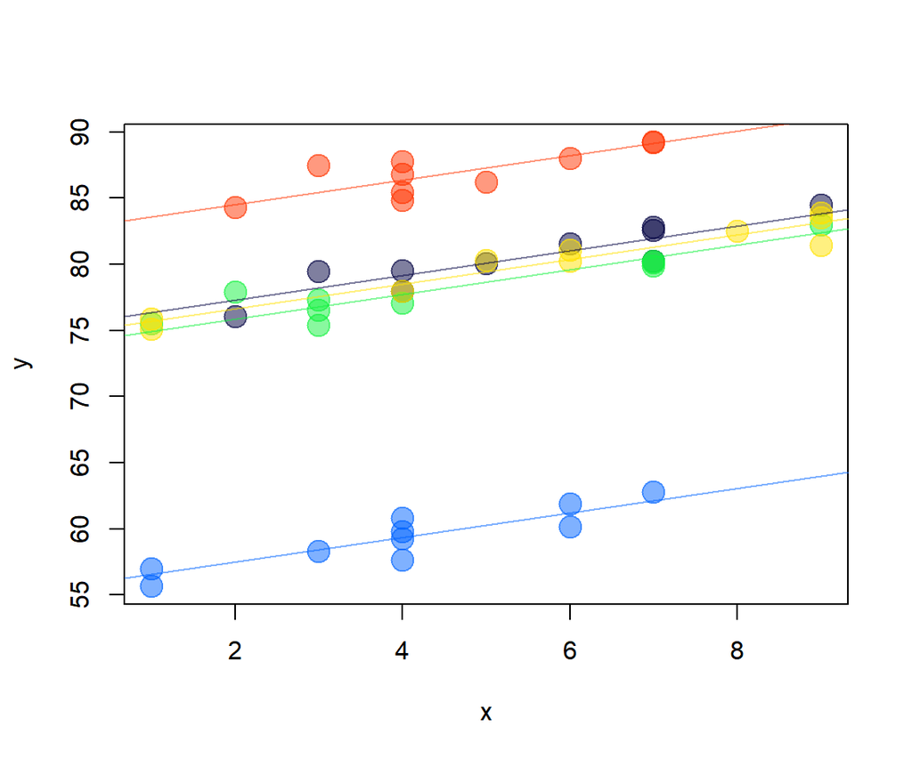

```r
coef <- coef(mod2)
with(dt, plot(y ~ x, pch=20, col=colores[dt$grupo], cex=3))
for (i in 1:5) abline(a=coef[i, 1], b=coef[i, 2], col=colores[i])
```

## Simulando datos con pendiente aleatoria

$$\begin{align*}
y_{ij} &\sim \mathcal{N}(\mu_{ij}, \sigma^2) \\
\mu_{ij} &= 59 + 1 \, x_{ij} + b_{1i} \, x_{ij} \\
\sigma &= 1 \\
b_1 &\sim \mathcal{N}(0, \sigma_{b1}) \\
x &\sim Uniforme[1, 9] \\
i &= 1, 2, \ldots, n_g, \quad j=1, 2, \ldots, n_i
\end{align*}$$

```r
sig <- 1
sd_b1 <- 5

ng <- 5
ni <- 10
n <- ng * ni

grupo <- rep(1:5, each=ni)
n <- ng * ni
x <- sample(1:9, size=n, replace=TRUE)
b1 <- rnorm(n=ng, mean=0, sd=sd_b0)
b1_rep <- rep(b0, each=ni)
media <- 59 + 1 * x + b1_rep * x
y <- rnorm(n=n, mean=media, sd=sig)

dt <- data.frame(grupo=grupo, x=x, b1_rep, y=y)
```

Exploremos lo que hay dentro de `dt`.

```r
dt[1:15, ]
```

```
##    grupo x    b1_rep         y
## 1      1 1 16.120339  75.98980
## 2      1 9 16.120339 212.91517
## 3      1 3 16.120339 110.83660
## 4      1 9 16.120339 212.56006
## 5      1 7 16.120339 179.33209
## 6      1 3 16.120339 110.58180
## 7      1 7 16.120339 179.48382
## 8      1 3 16.120339 110.16194
## 9      1 4 16.120339 127.05433
## 10     1 9 16.120339 214.25835
## 11     2 4 -3.119691  49.63964
## 12     2 1 -3.119691  56.94985
## 13     2 1 -3.119691  58.05509
## 14     2 5 -3.119691  49.11248
## 15     2 7 -3.119691  47.55556
```

Vamos a construir un diagrama de dispersión para los datos simulados.

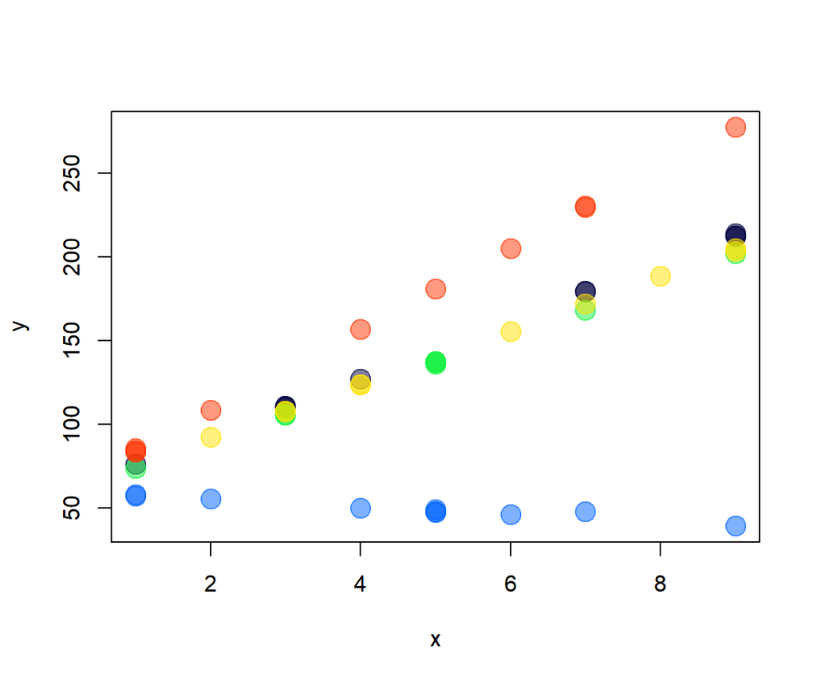

```r
with(dt, plot(y ~ x, pch=20, col=colores[dt$grupo], cex=3))
```

Ajustemos un modelo para recuperar el vector de parámetros parámetros $\boldsymbol{\Theta}$, para esto usemos la función `lme` del paquete `nlme`.

```r
mod3 <- lme(y ~ x, random = ~ -1 + x | grupo, data=dt)
summary(mod3)
```

```
## Linear mixed-effects model fit by REML
##  Data: dt
##        AIC      BIC    logLik
##   189.8101 197.2949 -90.90507
##
## Random effects:
##  Formula: ~-1 + x | grupo
##               x  Residual
## StdDev: 9.80007 0.9424285
##
## Fixed effects: y ~ x
##                Value Std.Error DF   t-value p-value
## (Intercept) 59.25474  0.285145 44 207.80582  0.0000
## x           14.22136  4.383034 44   3.24464  0.0022
##  Correlation:
##   (Intr)
## x -0.01
##
## Standardized Within-Group Residuals:
##         Min          Q1         Med          Q3         Max
## -1.79309023 -0.67567823 -0.08081208  0.47951526  3.45505069
##
## Number of Observations: 50
## Number of Groups: 5
```

Los efectos fijos estimados $\beta_0$ y $\beta_1$ se obtienen así:

```r
fixef(mod3)
```

```
## (Intercept)           x
##    59.25474    14.22136
```

```r
cbind(ranef(mod3), b1)
```

```
##            x        b1
## 1   2.893509 24.485320
## 2 -16.357833 11.171209
## 3   1.440636 -2.749943
## 4   1.898306 -5.799719
## 5  10.125382  6.523213
```

Usando los efectos fijos y los efectos aleatorios podemos obtener las expresiones ($\hat{\beta}_0 + \hat{\beta}_1 x_{ij} + b_{1i} x_{ij}$) para los modelos de cada grupo así:

```r
coef(mod3)
```

```
##   (Intercept)         x
## 1    59.25474 17.114868
## 2    59.25474 -2.136475
## 3    59.25474 15.661995
## 4    59.25474 16.119665
## 5    59.25474 24.346741
```

Usando la información anterior se puede dibujar el modelo ajustado para cada grupo.

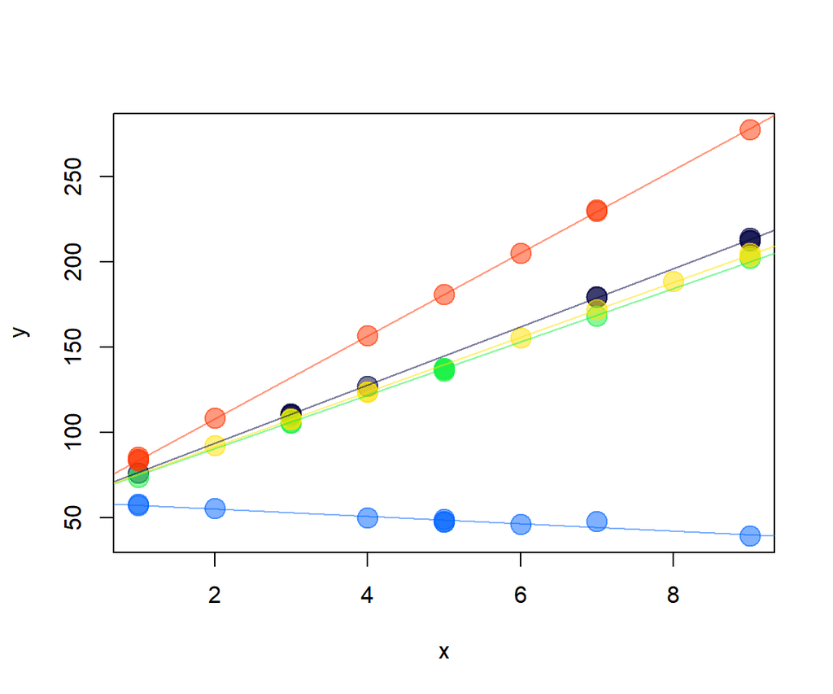

```r
coef <- coef(mod3)
with(dt, plot(y ~ x, pch=20, col=colores[dt$grupo], cex=3))
for (i in 1:5) abline(a=coef[i, 1], b=coef[i, 2], col=colores[i])
```

## Simulando datos con intercepto y pendiente aleatoria

Suponga que ahora queremos simular $n_i=10$ observaciones para $n_g=5$ grupos (en total 50) usando el siguiente modelo mixto con *intercepto y pendiente aleatoria* con vector de parámetros $\boldsymbol{\Theta}=(\beta_0=59, \beta_1=1, \sigma=1, \sigma_{b0}=9, \sigma_{b0}=4, \sigma_{b01}=-2)^\top$.

$$\begin{equation}
\begin{split}
y_{ij} &\sim \mathcal{N}(\mu_{ij}, \sigma^2), \\
\mu_{ij} &= 59 + 1 \, x_{ij} + b_{0i} + b_{1i} \, x_{ij} \\
\left (
\begin{matrix}
b_{0i} \\ b_{1i}
\end{matrix}
\right ) &\sim
\mathcal{N}\left ( \left ( \begin{matrix}
0 \\ 0
\end{matrix} \right ),
\left ( \begin{matrix}
\sigma^2_{b0} & \sigma_{b01} \\
\sigma_{b01} & \sigma^2_{b1}
\end{matrix} \right )
\right ) \\
x &\sim Uniforme[1, 9] \\
i &= 1, 2, \ldots, n_g \quad j=1, 2, \ldots, n_i
\end{split}
\end{equation}$$

```r
ng <- 5
ni <- 10
n <- ng * ni

sig <- 1

sd_b0 <- 9     # Matriz de covarianzas de los efectos aleatorios
sd_b1 <- 4
sd_b0b1 <- -2

library(MASS)
mu <- c(0, 0)
Sigma <- matrix(c(sd_b0^2, sd_b0b1, sd_b0b1, sd_b1^2), ncol=2)
b <- mvrnorm(n=ng, mu=mu, Sigma=Sigma)
b_rep <- b[rep(1:nrow(b), each=ni), ]

grupo <- rep(1:5, each=ni)
x <- sample(1:9, size=n, replace=TRUE)
media <- 59 + 1 * x + b_rep[, 1] + b_rep[, 2] * x
y <- rnorm(n=n, mean=media, sd=sig)

dt <- data.frame(grupo=grupo, x=x, b0=b_rep[, 1], b1=b_rep[, 2], y=y)
```

Exploremos lo que hay dentro de `dt`.

```r
dt[1:15, ]
```

```
##    grupo x        b0        b1        y
## 1      1 1 11.856987 -3.090478 68.19353
## 2      1 3 11.856987 -3.090478 65.84531
## 3      1 3 11.856987 -3.090478 65.46282
## 4      1 1 11.856987 -3.090478 69.51573
## 5      1 4 11.856987 -3.090478 62.23163
## 6      1 8 11.856987 -3.090478 54.23019
## 7      1 8 11.856987 -3.090478 53.98004
## 8      1 2 11.856987 -3.090478 65.41613
## 9      1 5 11.856987 -3.090478 61.60335
## 10     1 1 11.856987 -3.090478 67.09864
## 11     2 4  2.284471  3.291227 79.57652
## 12     2 1  2.284471  3.291227 65.20645
## 13     2 1  2.284471  3.291227 63.94286
## 14     2 7  2.284471  3.291227 91.46734
## 15     2 3  2.284471  3.291227 74.43226
```

Vamos a construir un diagrama de dispersión para los datos simulados.

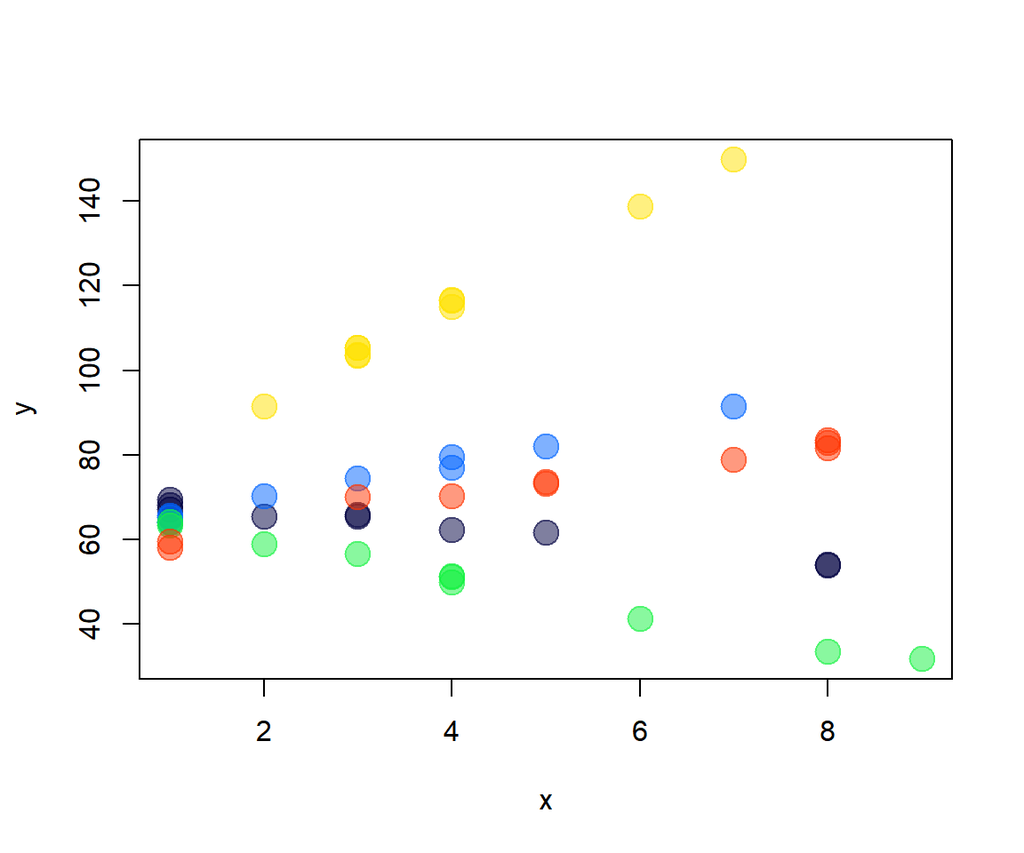

```r
with(dt, plot(y ~ x, pch=20, col=colores[dt$grupo], cex=3))
```

Ajustemos un modelo para recuperar el vector de parámetros parámetros $\boldsymbol{\Theta}$, para esto usemos la función `lme` del paquete `nlme`.

```r
mod4 <- lme(y ~ x, random = ~ 1 + x | grupo, data=dt)
summary(mod4)
```

```
## Linear mixed-effects model fit by REML
##  Data: dt
##        AIC     BIC    logLik
##   221.3988 232.626 -104.6994
##
## Random effects:
##  Formula: ~1 + x | grupo
##  Structure: General positive-definite, Log-Cholesky parametrization
##             StdDev   Corr
## (Intercept) 5.931193 (Intr)
## x           6.135197 -0.105
## Residual    1.138441
##
## Fixed effects: y ~ x
##                Value Std.Error DF   t-value p-value
## (Intercept) 65.12074   2.67457 44 24.348114  0.0000
## x            2.60250   2.74486 44  0.948137  0.3482
##  Correlation:
##   (Intr)
## x -0.108
##
## Standardized Within-Group Residuals:
##          Min           Q1          Med           Q3          Max
## -1.992475216 -0.623985821  0.001621968  0.594791769  2.908781616
##
## Number of Observations: 50
## Number of Groups: 5
```

Al igual que en los ejemplos anteriores, se puede dibujar el modelo ajustado para cada grupo.

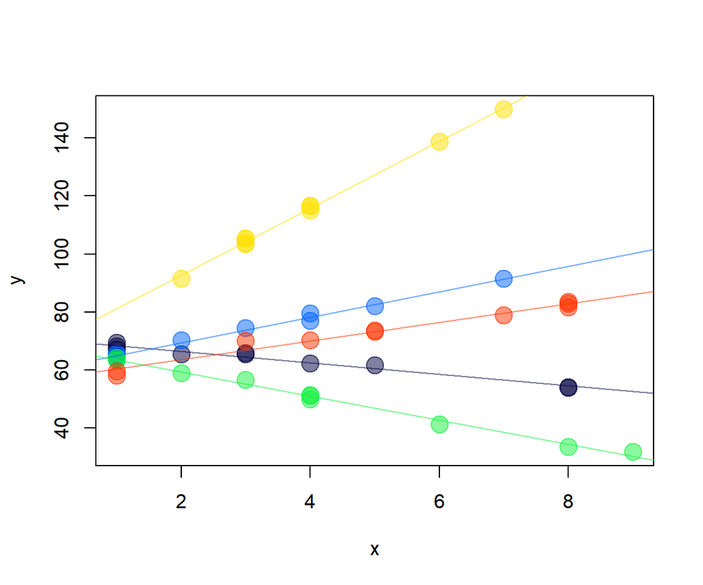

```r
coef <- coef(mod4)
with(dt, plot(y ~ x, pch=20, col=colores[dt$grupo], cex=3))
for (i in 1:5) abline(a=coef[i, 1], b=coef[i, 2], col=colores[i])
```

## Tarea

1. ¿Es posible que en un modelo mixto $y$ se distribuya *no normal*?
2. Consultar en la web ejemplos sencillos (con una sola covariable $x$) de modelos mixtos en los cuales la variable respuesta siga una distribución Poisson, binomial y gamma.
3. Para cada uno de los ejemplos encontrados, simular datos usando la estructura del ejemplo y luego estimar los parámetros.

Fin